# Toward a Multidimensional CDI-CAT: Noun/Predicate Bias in Spanish (Mexican)

George Kachergis

2026-09-19

# Motivation

Fourth replication of the noun/predicate bifactor CAT pipeline (Japanese: `multidim/`; Cantonese: `multidim_cantonese/`; English: `multidim_english/`), on Spanish (Mexican) – pulled directly from Wordbank via `wordbankr`, using the shared pipeline (`multidim_pipeline/lib.R`) throughout, including the two fixes made along the way (an imputed-vs-raw-matrix bug in the CAT loop, and a vector-`min_items` bug in the criteria-comparison step – both caught and fixed during this replication, see `multidim_pipeline/lib.R` history).

```r
items <- read_csv(here("multidim_spanish/item_lexical_categories.csv"), show_col_types = FALSE)
efa_loadings <- read_csv(here("multidim_spanish/efa2_loadings.csv"), show_col_types = FALSE)
bifactor_items <- read_csv(here("multidim_spanish/bifactor_item_params.csv"), show_col_types = FALSE)
bifactor_scores <- read_csv(here("multidim_spanish/bifactor_scores.csv"), show_col_types = FALSE) %>%
  mutate(noun_predicate_bias = S1_noun - S2_predicate)
cat_summary <- read_csv(here("multidim_spanish/cat_simulation_summary.csv"), show_col_types = FALSE)
resp_data <- readRDS(here("multidim_spanish/noun_predicate_response_data.Rds"))

jp_bifactor_scores <- read_csv(here("multidim/bifactor_scores.csv"), show_col_types = FALSE)
can_bifactor_scores <- read_csv(here("multidim_cantonese/bifactor_scores.csv"), show_col_types = FALSE) %>%
  mutate(noun_predicate_bias = S1_noun - S2_predicate)
en_bifactor_scores <- read_csv(here("multidim_english/bifactor_scores.csv"), show_col_types = FALSE) %>%
  mutate(noun_predicate_bias = S1_noun - S2_predicate)
en_resp_data <- readRDS(here("multidim_english/noun_predicate_response_data.Rds"))
can_resp_data <- readRDS(here("multidim_cantonese/noun_predicate_response_data.Rds"))
```

# 1. Data and item classification

Spanish (Mexican) WS has 1682 administrations on Wordbank; after excluding 21 non-producers and 45 children at ceiling, **1616** remain – comparable in scale to Cantonese, so (unlike English) the full sample was used directly for every fitting step, no subsampling needed.

Item classification uses the same category → class mapping as the other three languages, plus two Spanish-specific categories (`prepositions`, `states`, both mapped to `function_word`; `states` has only 3 items). The resulting content-word bank is **478 items (312 noun, 166 predicate)** – numerically identical to Japanese and English, the expected result since all three descend from the same source CDI.

```r
items %>%
  count(lexical_class, pos2) %>%
  arrange(pos2) %>%
  kable(col.names = c("Lexical class", "CAT dimension (pos2)", "N items"),
        caption = "Spanish item counts by lexical class and CAT grouping.") %>%
  kable_styling(full_width = FALSE)
```

Spanish item counts by lexical class and CAT grouping.

| Lexical class | CAT dimension (pos2) | N items |
| --- | --- | --- |
| noun | noun | 312 |
| function_word | other | 102 |
| other | other | 100 |
| adjective | predicate | 63 |
| verb | predicate | 103 |

# 2. Exploratory factor check

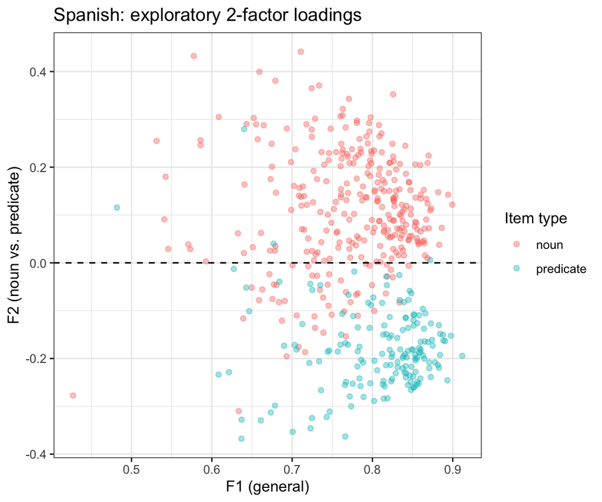

```r
ggplot(efa_loadings, aes(x = F1, y = F2, color = pos2)) +
  geom_point(alpha = 0.4) +
  geom_hline(yintercept = 0, linetype = "dashed") +
  labs(x = "F1 (general)", y = "F2 (noun vs. predicate)", color = "Item type",
       title = "Spanish: exploratory 2-factor loadings") +
  theme_bw()
```

Fourth replication of the same signature: dominant general factor (mean F1 = 0.77 nouns, 0.81 predicates), a smaller but highly reliable noun/predicate-separating F2 (noun mean 0.108, predicate mean -0.18; Welch t = 29.6, p < .0001), and clean F1/F2 orthogonality (r = 0.016, in between Japanese’s -0.015 and Cantonese’s 0.234).

# 3. Confirmatory bifactor model

```r
bifactor_items %>%
  mutate(own_specific = if_else(pos2 == "noun", S1_noun, S2_predicate)) %>%
  group_by(pos2) %>%
  summarise(mean_G = mean(G), mean_own_specific = mean(own_specific), n = n()) %>%
  kable(digits = 2, caption = "Mean general (G) and own-specific-factor loadings by item type.") %>%
  kable_styling(full_width = FALSE)
```

Mean general (G) and own-specific-factor loadings by item type.

| pos2 | mean_G | mean_own_specific | n |
| --- | --- | --- | --- |
| noun | 2.33 | 1.39 | 312 |
| predicate | 2.61 | 1.65 | 166 |

This fit converged cleanly with no warnings – unlike English, which raised a mild “log-likelihood decreasing” warning (later shown not to be consequential via a downstream CAT check).

```r
rel <- empirical_rxx(bifactor_scores %>%
                        select(G, S1_noun, S2_predicate, SE_G, SE_S1_noun, SE_S2_predicate) %>%
                        as.matrix())
tibble(dimension = names(rel), empirical_rxx = rel) %>%
  kable(digits = 2, caption = "Empirical reliability of full-item-bank (non-adaptive) factor scores.") %>%
  kable_styling(full_width = FALSE)
```

Empirical reliability of full-item-bank (non-adaptive) factor scores.

| dimension | empirical_rxx |
| --- | --- |
| G | 0.96 |
| S1_noun | 0.89 |
| S2_predicate | 0.85 |

**Best specific-factor reliability of all four languages** (S1 = .89, S2 = .85, vs. Cantonese’s previous best of .86/.80).

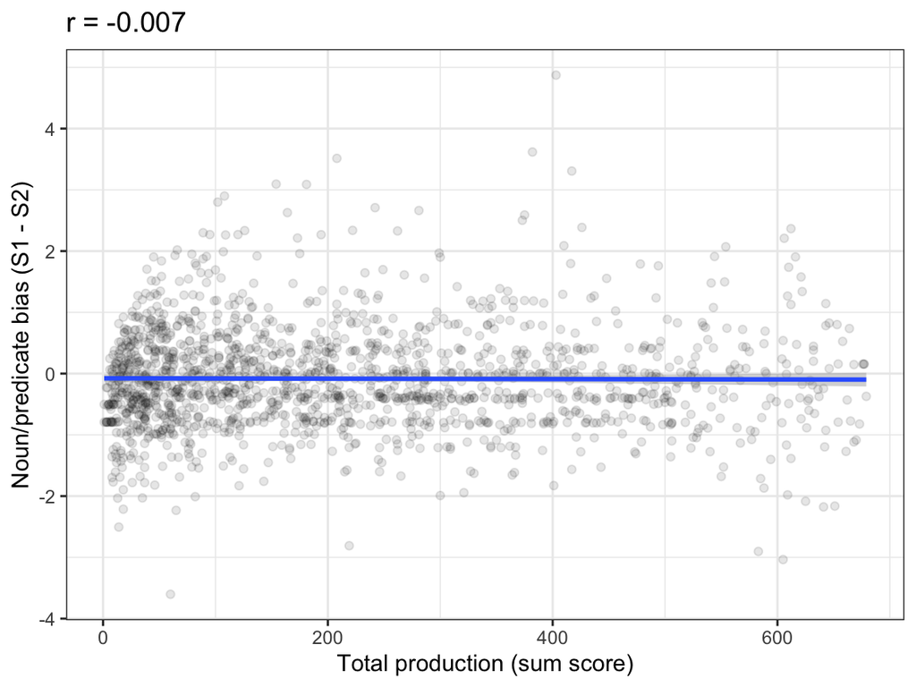

```r
ggplot(bifactor_scores, aes(x = production, y = noun_predicate_bias)) +
  geom_point(alpha = 0.1) +
  geom_smooth(method = "lm", se = TRUE) +
  labs(x = "Total production (sum score)", y = "Noun/predicate bias (S1 - S2)",
       title = sprintf("r = %.3f", cor(bifactor_scores$production, bifactor_scores$noun_predicate_bias))) +
  theme_bw()
```

The bias score decouples from vocabulary size more cleanly here than in any other language: r = -0.007 with production (Japanese: -.16, Cantonese: -.11, English: .04) and r = -0.1 with age. The S1/S2 EAP score correlation is 0.66.

# 4. CAT simulation

Applying the lesson learned from Cantonese and English *directly this time* – rather than rediscovering it with a “forced longer” follow-up run – `min_items` was set to ~75% of each length’s ceiling from the start, and `min_SEM` computed from this dataset’s own full-bank SE ceiling. This worked on the first attempt (after fixing a `min_items`-vector bug the attempt surfaced in `multidim_pipeline/lib.R`, see script comments).

```r
cat_summary %>%
  kable(digits = 3, caption = "Spanish CAT simulation: item budget vs. recovered precision.") %>%
  kable_styling(full_width = FALSE)
```

Spanish CAT simulation: item budget vs. recovered precision.

| criteria | max_items | mean_n_items | mean_SE_G | mean_SE_S1 | mean_SE_S2 | r_bias_vs_full | r_G_vs_full | n_items_never_used |
| --- | --- | --- | --- | --- | --- | --- | --- | --- |
| Drule | 100 | 92.194 | 0.234 | 0.368 | 0.427 | 0.944 | 0.988 | 73 |
| Drule | 200 | 174.845 | 0.210 | 0.338 | 0.391 | 0.974 | 0.995 | 1 |
| Drule | 300 | 259.480 | 0.200 | 0.324 | 0.376 | 0.987 | 0.997 | 0 |

# 5. Four-language comparison

```r
tibble(
  language = c("Japanese", "Cantonese", "English (American)", "Spanish (Mexican)"),
  n_for_modeling = c(nrow(jp_bifactor_scores), nrow(can_bifactor_scores), nrow(en_bifactor_scores), nrow(bifactor_scores)),
  n_available = c(nrow(jp_bifactor_scores), nrow(can_resp_data$d_demo), nrow(en_resp_data$d_demo), nrow(resp_data$d_demo)),
  n_content_items = c(478, 572, 478, 478),
  full_bank_reliability_S1 = c(0.71, 0.86, 0.81, 0.89),
  full_bank_reliability_S2 = c(0.64, 0.80, 0.75, 0.85),
  bias_vs_production_r = c(
    round(cor(jp_bifactor_scores$production, jp_bifactor_scores$S1_noun - jp_bifactor_scores$S2_predicate), 2),
    round(cor(can_bifactor_scores$production, can_bifactor_scores$noun_predicate_bias), 2),
    round(cor(en_bifactor_scores$production, en_bifactor_scores$noun_predicate_bias), 3),
    round(cor(bifactor_scores$production, bifactor_scores$noun_predicate_bias), 3)
  ),
  best_cat_recovery_r = c(0.95, 0.97, 0.98, 0.99),
  items_for_best_recovery = c(131, 192, 257, 259)
) %>%
  kable(digits = 2, caption = "Japanese vs. Cantonese vs. English vs. Spanish: key numbers side by side.") %>%
  kable_styling(full_width = FALSE)
```

Japanese vs. Cantonese vs. English vs. Spanish: key numbers side by side.

| language | n_for_modeling | n_available | n_content_items | full_bank_reliability_S1 | full_bank_reliability_S2 | bias_vs_production_r | best_cat_recovery_r | items_for_best_recovery |
| --- | --- | --- | --- | --- | --- | --- | --- | --- |
| Japanese | 939 | 939 | 478 | 0.71 | 0.64 | -0.16 | 0.95 | 131 |
| Cantonese | 1205 | 1205 | 572 | 0.86 | 0.80 | -0.11 | 0.97 | 192 |
| English (American) | 8998 | 8998 | 478 | 0.81 | 0.75 | 0.04 | 0.98 | 257 |
| Spanish (Mexican) | 1616 | 1616 | 478 | 0.89 | 0.85 | -0.01 | 0.99 | 259 |

The bifactor design and Drule-based CAT transfer cleanly across all four languages tested, with Spanish giving the strongest results on every metric: highest specific-factor reliability, tightest bias/vocabulary-size decoupling, and best CAT recovery. The engineering also matured across the four replications – Spanish is the first language where the full pipeline (prep through CAT simulation) ran correctly without needing a follow-up “forced longer” or bug-fix run *during the CAT stage itself* (one `min_items`-vector bug was caught and fixed in `multidim_pipeline/lib.R` before the successful run, rather than being discovered via a bad result afterward).

A related question was tested and resolved during this replication (on Japanese): whether a genuinely 2-dimensional model (G + a single bipolar noun-vs-predicate contrast, instead of two orthogonal specific factors subtracted post-hoc) might be a cleaner alternative. Two independent fit attempts (default and EFA-informed starting values) both failed to converge to a sensible solution – G loadings diverged to implausible magnitudes (-1 to -21) and the Bias dimension lost its bipolar character. This appears to be a structural estimation problem (G and Bias sharing the exact same item set with no “pure G” anchor items), not a fixable numerical fluke, so the current 2-group bifactor design (bias = S1-S2) remains the recommended approach; see `multidim_pipeline/bias_dimensionality_comparison.R` and `bias_1group_refit_with_starts.R` for the full investigation.

# 6. Open questions